# Exploratory Data Analysis

STOR 320.01 Group 1

March 21, 2025

# Creator: Tess Palmer

### Q1: Which crime types have the highest and lowest resolution rates (resolution being not classified as IC)?

```r
tp_resolution_rates <- crime %>%
  filter(!is.na(Status)) %>%
  group_by(Crm.Cd.Desc) %>%
  summarise(
    tp_total_cases = n(),
    tp_resolved_cases = sum(Status != "IC"),
    tp_resolution_rate = tp_resolved_cases / tp_total_cases
  ) %>%
  arrange(desc(tp_resolution_rate))

tp_highest_resolution <- tp_resolution_rates %>%
  head(10) %>%
  mutate(group = "Highest")
tp_lowest_resolution <- tp_resolution_rates %>%
  tail(10) %>%
  mutate(group = "Lowest")
tp_summary <- bind_rows(tp_highest_resolution, tp_lowest_resolution)
tp_summary
```

```
## # A tibble: 20 × 5
##    Crm.Cd.Desc         tp_total_cases tp_resolved_cases tp_resolution_rate group
##    <chr>                        <int>             <int>              <dbl> <chr>
##  1 DISHONEST EMPLOYEE…              1                 1              1     High…
##  2 MANSLAUGHTER, NEGL…              7                 7              1     High…
##  3 PANDERING                       85                72              0.847 High…
##  4 LYNCHING                        15                12              0.8   High…
##  5 INTIMATE PARTNER -…           8868              6923              0.781 High…
##  6 CHILD STEALING                 316               242              0.766 High…
##  7 CHILD NEGLECT (SEE…            797               595              0.747 High…
##  8 CHILD ABUSE (PHYSI…           2423              1802              0.744 High…
##  9 CHILD ABUSE (PHYSI…            437               323              0.739 High…
## 10 BRIBERY                          7                 5              0.714 High…
## 11 BIKE - ATTEMPTED S…              6                 0              0     Lowe…
## 12 DRUNK ROLL                      18                 0              0     Lowe…
## 13 FAILURE TO DISPERSE              2                 0              0     Lowe…
## 14 GRAND THEFT / AUTO…              3                 0              0     Lowe…
## 15 INCITING A RIOT                  1                 0              0     Lowe…
## 16 PICKPOCKET, ATTEMPT              3                 0              0     Lowe…
## 17 THEFT, COIN MACHIN…              5                 0              0     Lowe…
## 18 THEFT, COIN MACHIN…              5                 0              0     Lowe…
## 19 THEFT, COIN MACHIN…             16                 0              0     Lowe…
## 20 TILL TAP - PETTY (…             15                 0              0     Lowe…
```

### Q2: Which age group is most frequently targeted in crimes? Age groups are defined as under 5 years, 5-17 years, 18-24 years, 25-34 years, 35-44 years, 45-64 years, 65-84 years, 85-99 years, and 100+ years (using the age groups used by the U.S. Census).

```r
tp_crime_age_data <- crime %>%
  filter(!is.na(Vict.Age), Vict.Age > 0) %>%
  mutate(tp_age_group = ifelse(Vict.Age < 5, "Under 5 years",
                     ifelse(Vict.Age <= 17, "5-17 years",
                     ifelse(Vict.Age <= 24, "18-24 years",
                     ifelse(Vict.Age <= 34, "25-34 years",
                     ifelse(Vict.Age <= 44, "35-44 years",
                     ifelse(Vict.Age <= 64, "45-64 years",
                     ifelse(Vict.Age <= 84, "65-84 years",
                     ifelse(Vict.Age <= 99, "85-99 years", "100+ years")))))))))

tp_age_group_counts <- tp_crime_age_data %>%
  group_by(tp_age_group) %>%
  summarise(tp_tp_crime_count = n()) %>%
  arrange(desc(tp_tp_crime_count))
tp_age_group_counts
```

```
## # A tibble: 9 × 2
##   tp_age_group  tp_tp_crime_count
##   <chr>                     <int>
## 1 25-34 years              136278
## 2 45-64 years              130396
## 3 35-44 years              107919
## 4 18-24 years               62143
## 5 65-84 years               33691
## 6 5-17 years                16121
## 7 85-99 years                2479
## 8 Under 5 years              1000
## 9 100+ years                    1
```

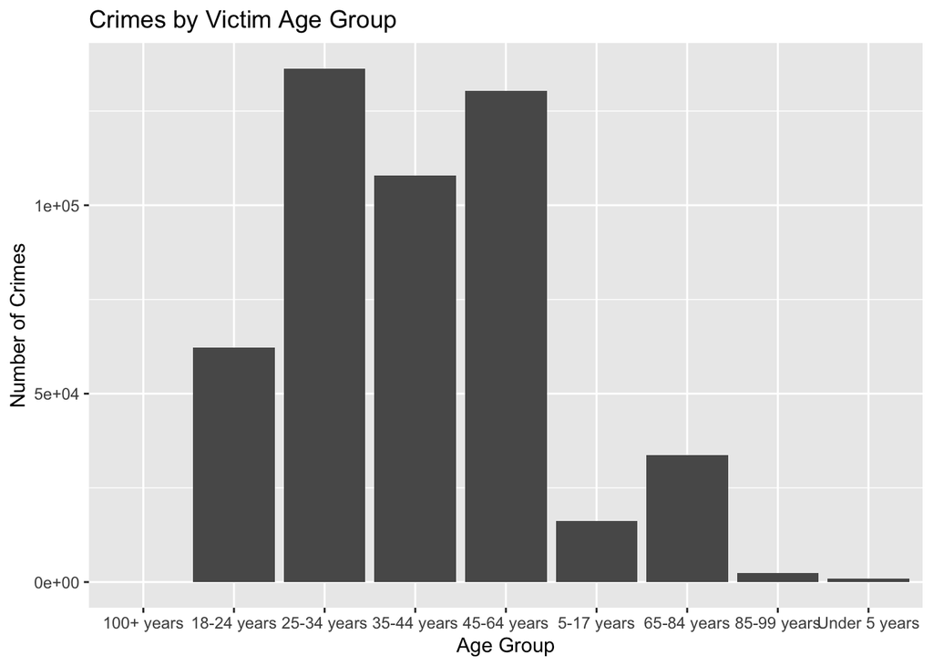

```r
ggplot(tp_crime_age_data, aes(x = tp_age_group)) +
  geom_bar() +
  labs(
    title = "Crimes by Victim Age Group",
    x = "Age Group",
    y = "Number of Crimes"
  )
```

# Interpreter: Sydney Schaefer

### Q1: Are there specific areas experiencing higher crime rates, and what proportion of total reported crimes do these areas account for?

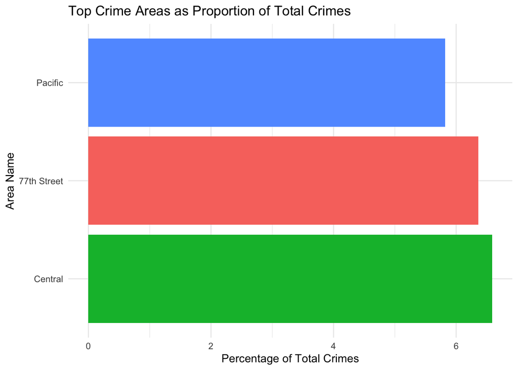

```r
SS_crime_area <- crime %>%
  rename(area_name = AREA.NAME) %>%
  group_by(area_name) %>%
  summarize(area_count = n()) %>%
  arrange(desc(area_count))

SS_percentile_90 <- quantile(SS_crime_area$area_count, 0.90)

SS_top_areas <- SS_crime_area %>%
  filter(area_count >= SS_percentile_90)

crime_count <- sum(SS_crime_area$area_count)

top_areas <- SS_top_areas %>%
  mutate(proportion = area_count / crime_count)

ggplot(top_areas, aes(x = reorder(area_name, -proportion), y = proportion * 100, fill = area_name)) +
  geom_bar(stat = "identity") +
  labs(title = "Top Crime Areas as Proportion of Total Crimes",
       x = "Area Name",
       y = "Percentage of Total Crimes") +
  theme_minimal() +
  coord_flip() +
  theme(legend.position = "none")
```

### Q2: Are there significant seasonal variations in crime rates, and do these trends differ by crime type?

```r
crime_seasons <- crime %>%
  mutate(date = mdy_hms(DATE.OCC)) %>%
  separate(date, into = c("year", "month", "day"), sep = "-") %>%
  mutate(season = case_when(
      month %in% c("12", "01", "02") ~ "Winter",
      month %in% c("03", "04", "05") ~ "Spring",
      month %in% c("06", "07", "08") ~ "Summer",
      month %in% c("09", "10", "11") ~ "Fall"))

(seasonal_crime <- crime_seasons %>%
  group_by(season) %>%
  summarize(count = n()) %>%
  arrange(desc(count)))
```

```
## # A tibble: 4 × 2
##   season  count
##   <chr>   <int>
## 1 Summer 165815
## 2 Fall   162294
## 3 Spring 158637
## 4 Winter 158228
```

```r
top_10_crime_types <- crime %>%
  rename(crime_type = Crm.Cd.Desc) %>%
  group_by(crime_type) %>%
  summarize(count = n()) %>%
  arrange(desc(count)) %>%
  slice_head(n = 10)

(seasonal_crime_type <- crime_seasons %>%
  rename(crime_type = Crm.Cd.Desc) %>%
  filter(crime_type %in% top_10_crime_types$crime_type) %>%
  group_by(season, crime_type) %>%
    summarize(count = n()) %>%
    arrange(season, desc(count)))
```

```
## # A tibble: 40 × 3
## # Groups:   season [4]
##    season crime_type                                              count
##    <chr>  <chr>                                                   <int>
##  1 Fall   VEHICLE - STOLEN                                        17808
##  2 Fall   BATTERY - SIMPLE ASSAULT                                12829
##  3 Fall   THEFT OF IDENTITY                                       10926
##  4 Fall   VANDALISM - FELONY ($400 & OVER, ALL CHURCH VANDALISMS)  9823
##  5 Fall   ASSAULT WITH DEADLY WEAPON, AGGRAVATED ASSAULT           9672
##  6 Fall   BURGLARY FROM VEHICLE                                    9650
##  7 Fall   BURGLARY                                                 9518
##  8 Fall   INTIMATE PARTNER - SIMPLE ASSAULT                        8281
##  9 Fall   THEFT PLAIN - PETTY ($950 & UNDER)                       8025
## 10 Fall   THEFT FROM MOTOR VEHICLE - PETTY ($950 & UNDER)          5967
## # ℹ 30 more rows
```

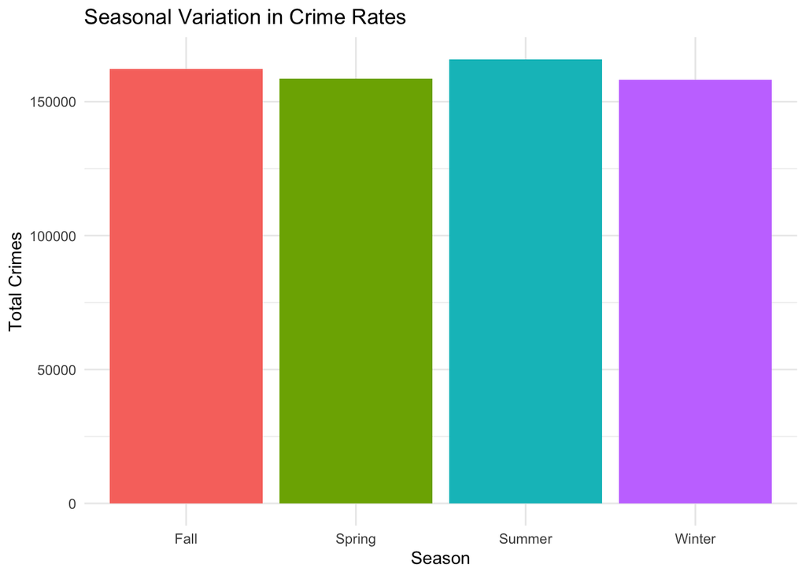

```r
ggplot(seasonal_crime, aes(x = season, y = count, fill = season)) +
  geom_bar(stat = "identity") +
  labs(title = "Seasonal Variation in Crime Rates",
       x = "Season",
       y = "Total Crimes") +
  theme_minimal() +
  theme(legend.position = "none")
```

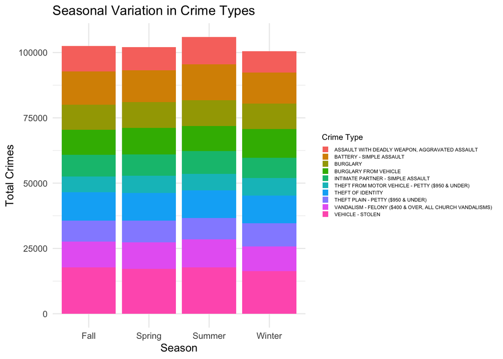

```r
ggplot(seasonal_crime_type, aes(x = season, y = count, fill = crime_type)) +
  geom_bar(stat = "identity") +
  labs(title = "Seasonal Variation in Crime Types",
       x = "Season",
       y = "Total Crimes",
       fill = "Crime Type") +
  theme_minimal() +
  theme(legend.key.size = unit(0.5, "lines"),
        legend.text = element_text(size = 5),
        legend.title = element_text(size = 8))
```